# Taking advantage of all the symbols in ggplot2

There are a few things in R that are particularly annoying and I have left them all to the last steps. This is the case for any package or set of tools we choice to use as researchers. The issues below are a random collection of issues do with the tidyverse approach and the other packages I use to do analysis. Here are my learning steps for the annoying R issues.

# `ggplot2` symbols

I have been writing my first paper for my PhD for a ridiculously long time and as I am finally finishing figures for the manuscript I have had huge issues trying to sort these symbols.

## My solution for this script

### `aes(shape = Valley; colour = Control, fill = Rats)`

Overll the three factors ploted as colours looks like so:

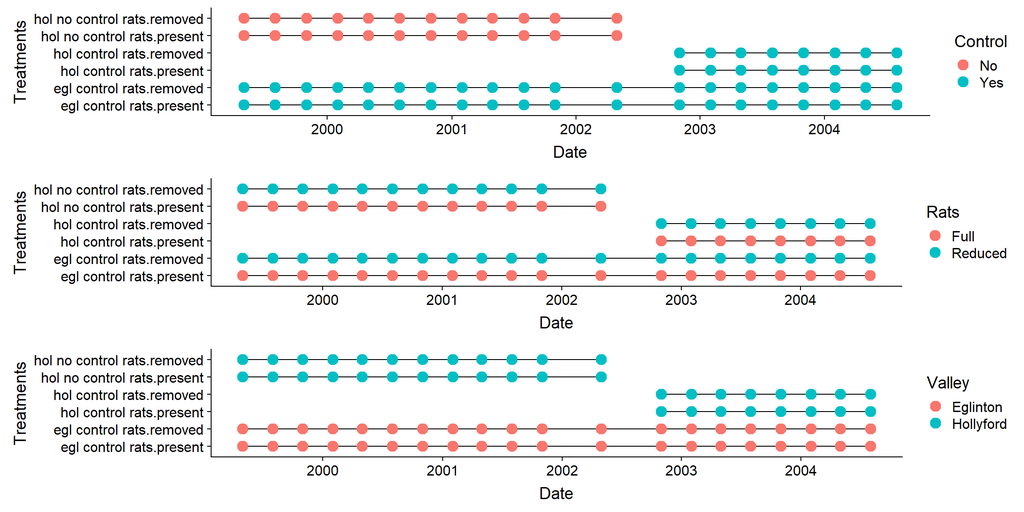

Figure 1: Plot of the three different factors, each with two levels that I want to each have the following representative symbols

For the example above there are three factors (valley, control, rats) each has 2 levels. However, because we are missing some combinations we have a total of 6 treatments.

## `aes(shape = Valley; colour = Control)`

To plot this I need to split the symbols. I have decided to do this as follows: `shape = Valley`; `colour = Control`; `fill = Rats`. And in ggplot2 this is wrapped with the `aes()` function.

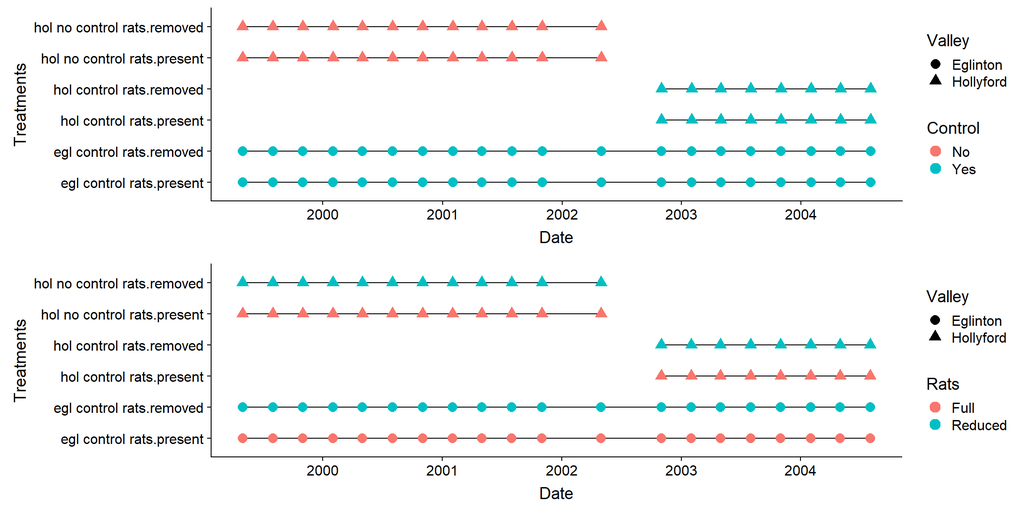

Figure 2: PLots including shape for Valley but two different plots showing the different factors in Control and Rats factors

## `aes(shape = Valley; colour = Control, fill = Rats)`

And in ggplot2 this is wrapped with the `aes(shape = Valley; colour = Control, fill = Rats)` function. And then it looks like this:

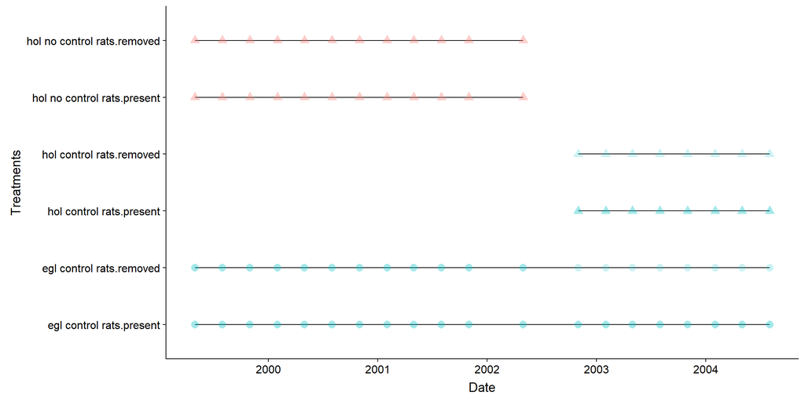

Figure 3: Attempting to understand why the colouring is not working with fill

**WHAT makes this such a hard question??**

But for some reason fill doesn’t work the way I want with rings for rats!

## Working out plots space

Working with factors below to check this is not the issue.

[output not shown]

```
 chr [1:144] "Eglinton" "Eglinton" "Eglinton" "Eglinton" "Eglinton" ...
```

[output not shown]

[output not shown]

```
 chr [1:144] "Yes" "Yes" "Yes" "Yes" "Yes" "Yes" "Yes" "Yes" "Yes" ...
```

[output not shown]

[output not shown]

```
 chr [1:144] "Reduced" "Reduced" "Reduced" "Reduced" "Reduced" ...
```

[output not shown]

```
, ,  = Full


            No Yes
  Eglinton   0  40
  Hollyford 24  16

, ,  = Reduced


            No Yes
  Eglinton   0  32
  Hollyford 24   8
```

IN this case the issue is exactly that to do with the 8 grids and the 6 treatments across 20 time intervals.

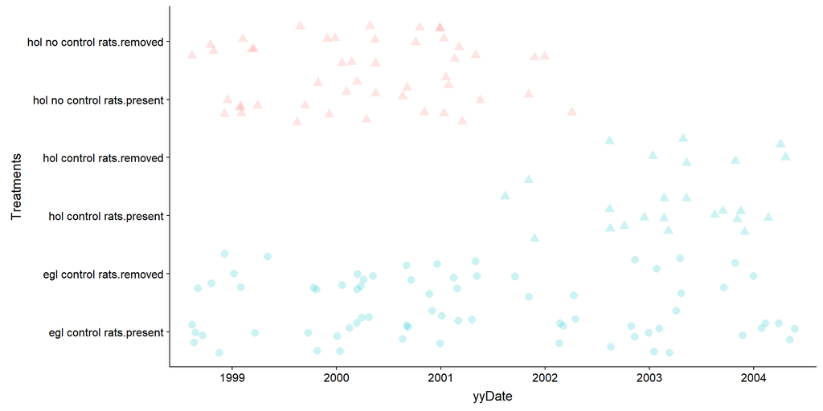

- I am confused about these replicates but none are as complex is what I have here.

## Solutions

1. First issue is that it is by grid not treatment

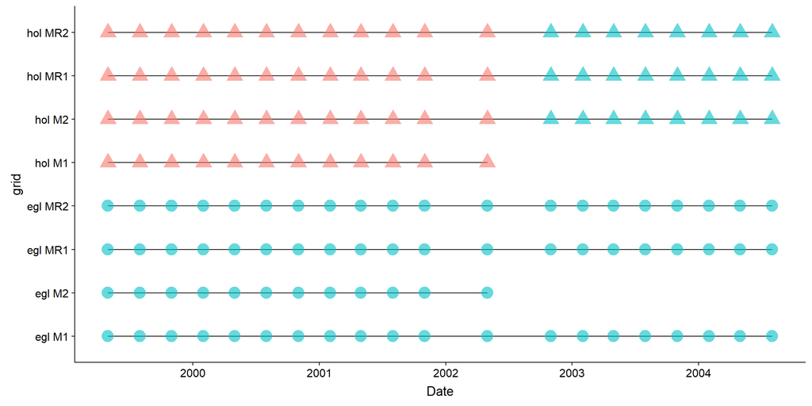

## This is why?? I had a look at examples I could find that have done this and the following stack-exchange and other blogs helped to produce this:

EXEPT ONE [here](http://www.audhalbritter.com/complicated-figure/)

or a few more options…

2. And it turns out you can do this by creating a dumby variable
3. Or change alpha to 0.5 so solid lines come up?
4. Or us alpha as facet
5. Change size of some just slightly so can see black?

[output not shown]

```
 chr [1:144] "Eglinton" "Eglinton" "Eglinton" "Eglinton" "Eglinton" ...
```

[output not shown]

[output not shown]

```
 chr [1:144] "Yes" "Yes" "Yes" "Yes" "Yes" "Yes" "Yes" "Yes" "Yes" ...
```

[output not shown]

[output not shown]

```
 chr [1:144] "Reduced" "Reduced" "Reduced" "Reduced" "Reduced" ...
```

[output not shown]

```
, ,  = Full


            No Yes
  Eglinton   0  40
  Hollyford 24  16

, ,  = Reduced


            No Yes
  Eglinton   0  32
  Hollyford 24   8
```

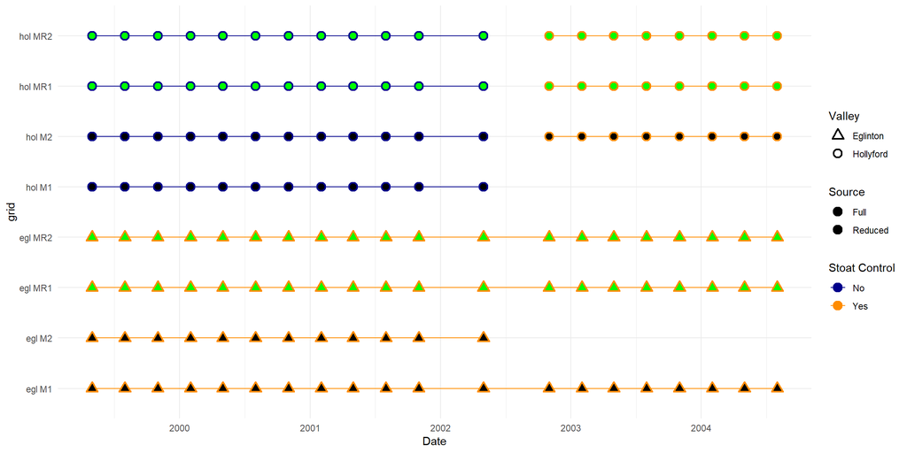

## Resources

Dealing with factors can be hard in R and here are some resources for FACTORS in R:

- [A collection of scripts I use](https://github.com/davan690/usefulr/)
- [An .Rmd file for factoring](https://github.com/davan690/usefulr/tree/gh-pages/RMarkdown-vigettes)
- Simple example 1

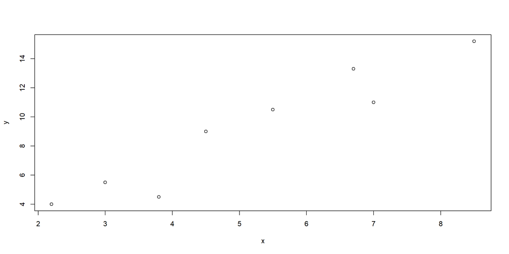

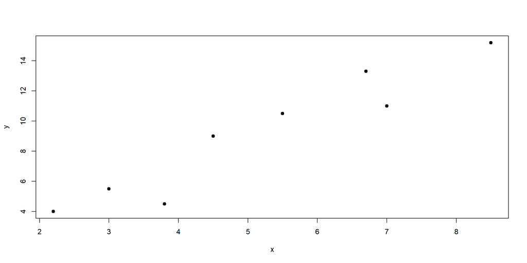

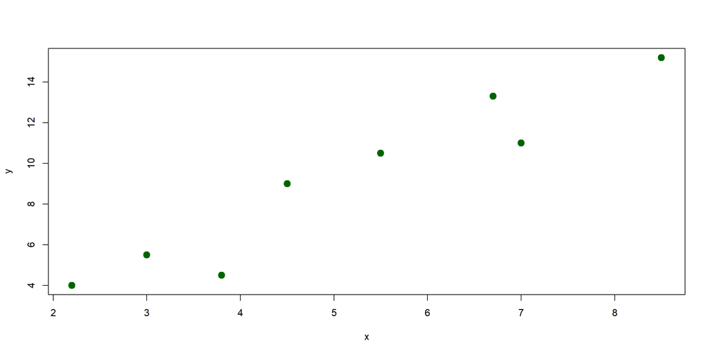

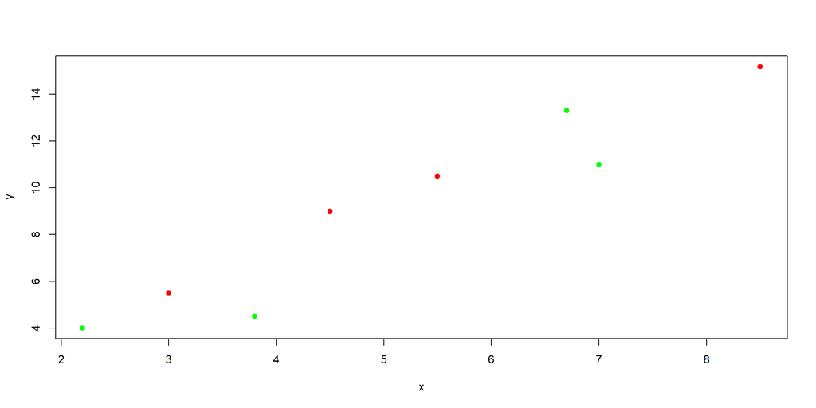

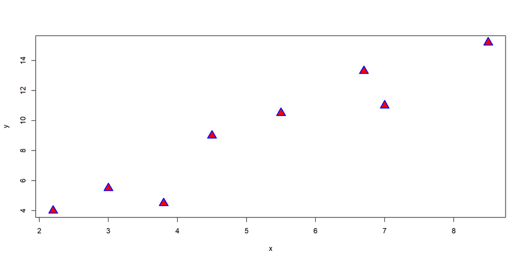

  |  | mpg | cyl | wt |
  | --- | --- | --- | --- |
  | Mazda RX4 | 21.0 | 6 | 2.620 |
  | Mazda RX4 Wag | 21.0 | 6 | 2.875 |
  | Datsun 710 | 22.8 | 4 | 2.320 |
  | Hornet 4 Drive | 21.4 | 6 | 3.215 |
  | Hornet Sportabout | 18.7 | 8 | 3.440 |
  | Valiant | 18.1 | 6 | 3.460 |

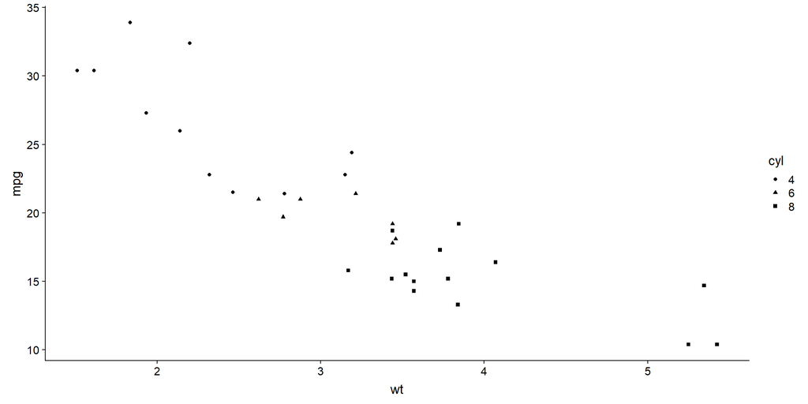

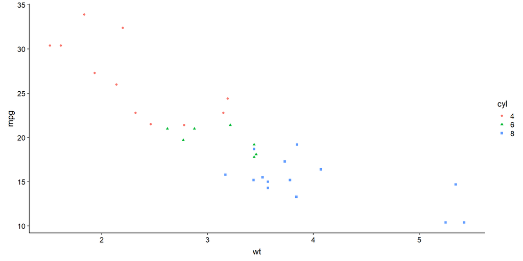

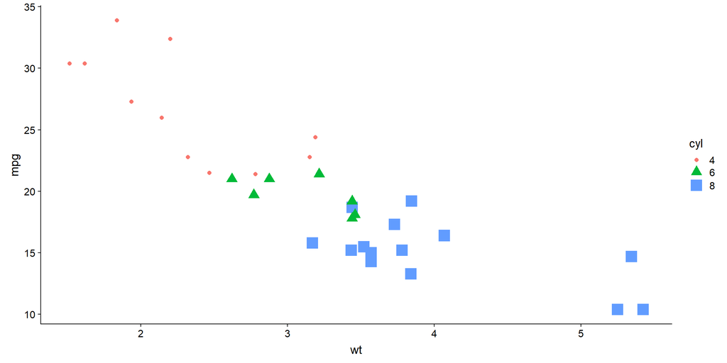

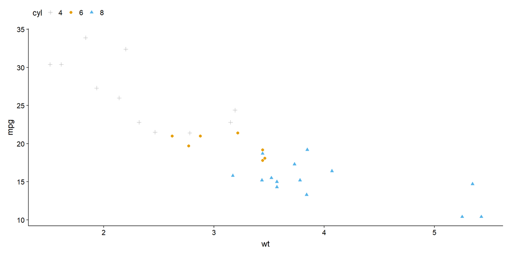

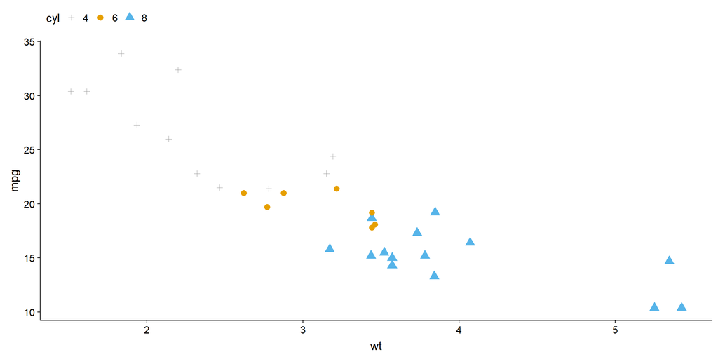

- Simple example 2

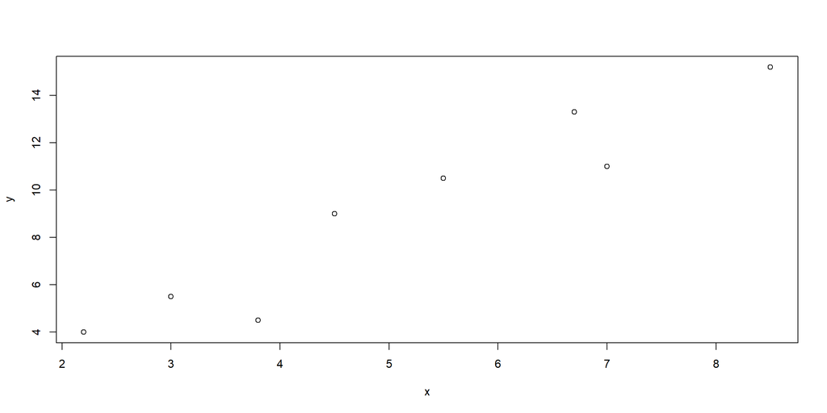

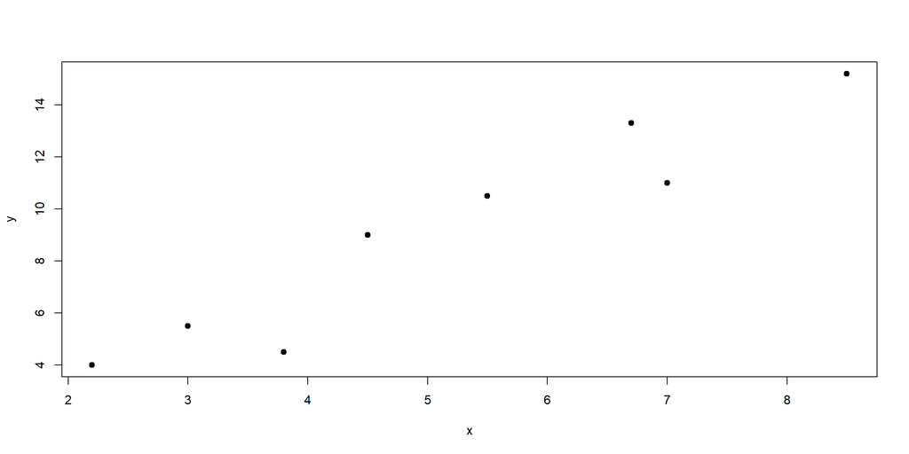

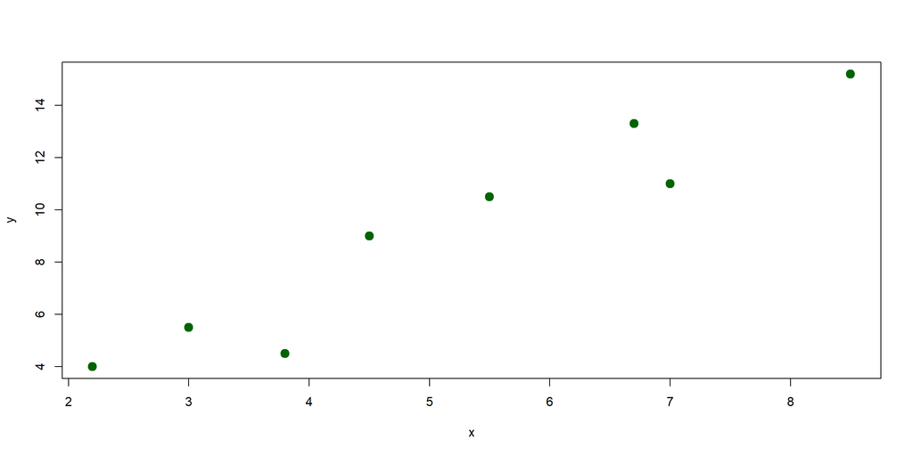

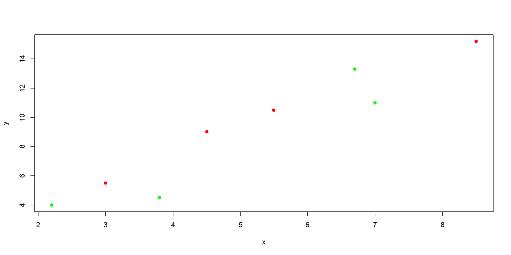

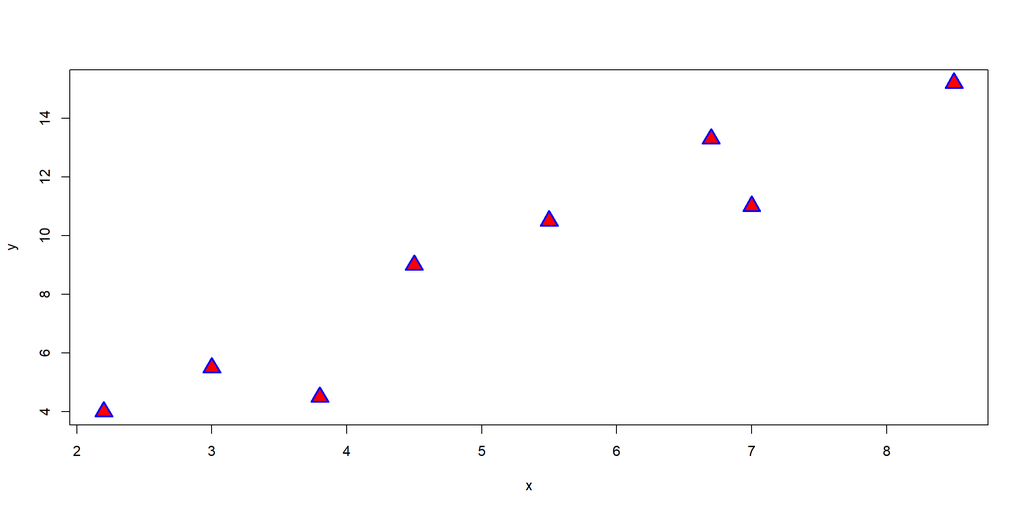

- Complex fill solution

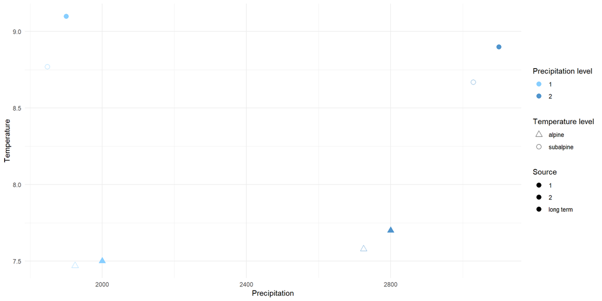

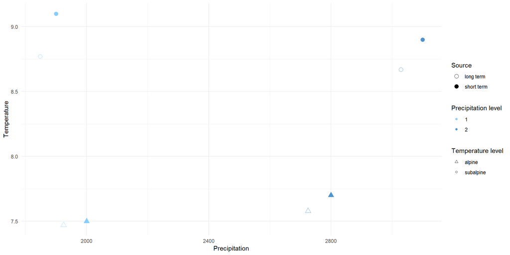